# Predicting Cognitive Occupation Placement: A Machine Learning Approach

Ireland Gomes

2026-02-19

## 1 Introduction

This machine learning analysis examines the predictors of cognitive occupation placement among full-time workers in the United States. Using individual-level data from the 2019 American Community Survey (ACS) and occupational skill ratings from the O*NET database, I construct a measure at the occupational level of cognitive work demands and use it to classify workers into high and low cognitive demand occupations. Then, three machine learning models, specifically logistic regression, LASSO-penalized regression and XGBoost, are applied to the merged data set in an attempt to predict what kind of workers end up in high cognitive occupations based on variables such as their education, demographics, industry of employment, and geographic location.

Who accesses cognitively demanding work is a long-standing, central question in labor economics. Occupations with high demand for strong cognitive skills tend to offer higher wages, greater job security, and more opportunities for advancement. Our ability to understand the individual-level characteristics that potentially predict placement into these occupations, and how much of that predictability is captured by simple linear relationships versus complicated, nonlinear characteristic interactions has direct implications on how we think about credentialing, signaling, and the role of education in labor market sorting.

The predictive results across all three models indicate a consistent and interpretable story. Education credentials, specifically the presence or absence of a college degree, show to be the single strongest predictor of cognitive occupation placement, with industry assortment mattering almost as much. Additionally, demographic discrepancies by race and sex are persistent even after controlling for education, industry, English proficiency, and geographic location. Most striking, however, is that a simple logistic regression model performs nearly identically to XGBoost, an econometric ensemble method capable of capturing complex nonlinear relationships. This suggests that the structure of this prediction problem is largely linear. Furthermore, having all models in strong consensus on which variables hold the most predictive power lends significant robustness to their conclusions.

## 2 Data

### 2.1 Sources

To execute this project, two data sources were drawn upon and then merged at the occupation level: the 2019 American Community Survey (ACS) from Integrated Public Use Microdata Series (IPUMS) and the O*NET Skills database.

The ACS is a large-scale annual survey administered by the U.S. Census Bureau, used to collect detailed demographic, economic, and housing information from a representative sample of the U.S. population. These survey results provide my models with individual-level data on educational attainment, industry of employment, occupation, race, sex, age, English proficiency, nativity, citizenship status, and hours worked, among many other variables; the primary source of individual-level worker characteristics in this project.

Though available and complete for each year of the 21st century, at the minimum, I intentionally chose to use ACS data from 2019. By this year, the U.S. labor market had reached near-full employment and the unemployment rate stood at 3.5%, the lowest it has been since 1969, suggesting that individuals were sorting into their occupation with closer alignment to their their productive capacity and labor preferences rather than being displaced into whatever became available.

Just as importantly, using 2019 data allows me to avoid absorbing pandemic related shocks into my models. The profound disruptions resulting from COVID-19 dramatically altered labor market composition, occupational demand, remote work patterns, and educational attainment trajectories in ways that would be both very difficult to theoretically disentangle and econometrically messy to control for. The 2019 ACS therefore offers an especially clean snapshot of equilibrium labor market sorting under favorable macroeconomic conditions.

O*NET, the Occupational Information Network, is a database managed and created by Department of Labor. It’s widely regarded as the most comprehensive source of standardized occupational characteristics available. Rather than describing those of individual workers, O*NET describes attributes of occupations themselves through a structured rating system in which occupational analysts and incumbent workers evaluate each occupation across hundreds of standardized descriptors such as skills, knowledge domains, work activities, work context, and required abilities. Each descriptor is rated primarily on two scales: the importance scale and the level scale. For this analysis, ‘importance’, which captures how critical a given skill or activity is to effectively performing the job, is the scale of focus.

Both O*NET and the Census Bureau in the ACS organize occupations using the Standard Occupational Classification (SOC) system, making it feasible to merge occupation-level skill ratings from O*NET onto individual workers in the ACS.

### 2.2 Outcome Construction

The outcome variable in this project is a binary indicator of whether a worker is employed in a high or low cognitive occupation. Constructing this variable requires first building a continuous measure of cognitive work demands at the occupation level from O*NET, and then thresholding that measure into a binary classification.

#### 2.2.1 The Cognitive Skill Index

Some occupations demand sustained analytical reasoning, the ability to synthesize complex information, and the capacity to generate novel solutions to non-routine problems. Others are defined primarily by physical execution, and variations of procedural repetition with minimal analytical requirements. Thus, because not all work is cognitively equivalent, the purpose of the creating the cognitive skill index is to capture this distinction in an intentional and replicable way.

From the O*NET Skills database, I extract importance ratings for six skill items that together, operationalize cognitive work demands: critical thinking, complex problem solving, active learning, reading comprehension, writing, and mathematics. I selected these six items because as a collective, they span the core dimensions of non-routine cognitive labor as it appears in economics literature on occupational task content; analytical reasoning, information processing, communication, and quantitative competency. Each skill item is rated on O*NET’s importance scale from 1 to 5. The cognitive skill index for each occupation is computed as the average of these six importance ratings, which yields a continuous score that captures the overall cognitive demand profile for each specific occupation.

#### 2.2.2 Thresholding into a Binary Outcome

The continuous skill index is then converted into a binary outcome, done by splitting occupations at the median score. Occupations with a skill index greater than or equal to the median index are classified as high cognitive; those below are classified as low cognitive. This produced a roughly balanced outcome in the sample, with approximately 46% of workers classified as being in low cognitive occupations and 54% in high cognitive occupations , which is favorable for classification modeling.

It’s important to note that the choice to use the median as the threshold wasn’t arbitrary. The distribution of cognitive scores across occupations is very notably bimodal, with one cluster of occupations peaking around a score of 3.0 and a larger cluster peaking around 3.5. The median threshold falls naturally in the valley between these two clusters, meaning it separates two legitimately distinct groups of occupations rather than making some artificial cut through a unimodal distribution. This helps to lend additional validity to the binary classification of the outcome variable; high and low cognitive groups correspond to a real, structural feature of the occupational skill distribution present in the data rather than an arbitrary modeling choice I was left to make.

### 2.3 Sample Construction

The raw 2019 ACS extract from IPUMS contains all surveyed individuals regardless of employment status, age, or work intensity, but several restrictions were applied to the data both at the time of extraction and when cleaning to arrive at the sample used for analysis.

First, I restricted it to workers between the ages of 25 and 64. This excludes the lower bound of the age distribution which is composed of individuals who are primarily either not of working age, still completing their education, or have not yet made stable transitions into their career. The upper bound excludes individuals who are approaching or have passed the typical retirement age. Second, only individuals who work full-time hours, as defined by working 35 hours or more, are retained in the data. In doing so, part time workers whose occupational placement is more plausibly influenced by constraints unrelated to the capacity of their own labor or demographics are effectively excluded from the sample.

#### 2.3.1 Merging O*NET Cognitive Scores onto IPUMS Workers

Linking O*NET occupational ratings to individual workers in the ACS requires matching the occupation codes. O*NET data uses 8-digit SOC codes in the format “11-1011.00”, whereas IPUMS records occupation using a cleaned 6-digit numeric format originating from the same 8-digit SOC codes used by O*NET. After removing punctuation and truncating O*NET codes to 6 digits, I attempted an initial direct match for each worker, however a portion of IPUMS occupation codes could not be matched directly at the 6-digit level. Looking at the unmatched codes revealed two places of discrepancy: aggregate wildcard codes used by the Census to protect confidentiality, and legitimate SOC codes that simply had no direct O*NET link at the 6-digit level. I recovered the latter through a 4-digit fallback; where a 6-digit match was unavailable, the cognitive score was calculated as the average across all O*NET occupations that share the same 4-digit SOC prefix. This two-stage matching isn’t uncommon when using O*NET data. By doing so, a large majority of observations that would otherwise have been dropped, were recovered.

The final analytic sample contains approximately 802,000 individual workers, each with complete information across all specified IPUMS variables and a cognitive occupation score.

### 2.4 Feature Engineering

#### 2.4.1 Education and Degree Field

Education attained is categorized into nine ordered levels: less than high school, GED, high school diploma, some college, associate’s degree, bachelor’s degree, master’s degree, professional degree, and doctoral degree. For workers who hold a college degree, the field of their degree is categorized into eight groups: STEM Engineering, STEM Science, STEM Math and Computer Science, Social Science, Humanities, Education, Business, and Other. Workers without a college degree are assigned a separate “no degree” category to make ‘degree field’ an indicator of both credential attainment and field of study.

#### 2.4.2 Industry

Industry is recoded into fourteen generalized sectors, and is included as a predictor because occupational cognitive demands are heavily clustered by sector. A worker in the finance industry is far more likely to hold a high cognitive occupation than a worker in Retail Trade regardless of their individual characteristics. Failing to account for industry would leave a major source of variation unaccounted for.

#### 2.4.3 Race, Ethnicity, and English Proficiency

Race is categorized into four groups; White, Black, Asian, and Other. Hispanic ethnicity is coded separately as a binary indicator, which is consistent with the standard Census treatment of Hispanic identity as an ethnicity that cuts across racial categories rather than a racial group itself.

English proficiency is recoded into five level categories ranging from English only to does not speak English at all. This variable captures a dimension of labor market access that is distinct from nativity and citizenship. A worker, though foreign-born, could be a naturalized citizen who speaks fluent English, or could be a recent arrival with limited proficiency, and these distinctions carry very different, and meaningful implications for occupational placement outcomes. Nativity and citizenship status are included separately as additional predictors.

#### 2.4.4 Remaining Predictors

Sex is included as a binary indicator. Age is included as a continuous variable to capture the tendency for workers to sort into better-matched occupations over the course of their careers. Metropolitan area and state are included as factor variables to absorb the geographic variation present in local labor market composition.

## 3 Descriptive Statistics

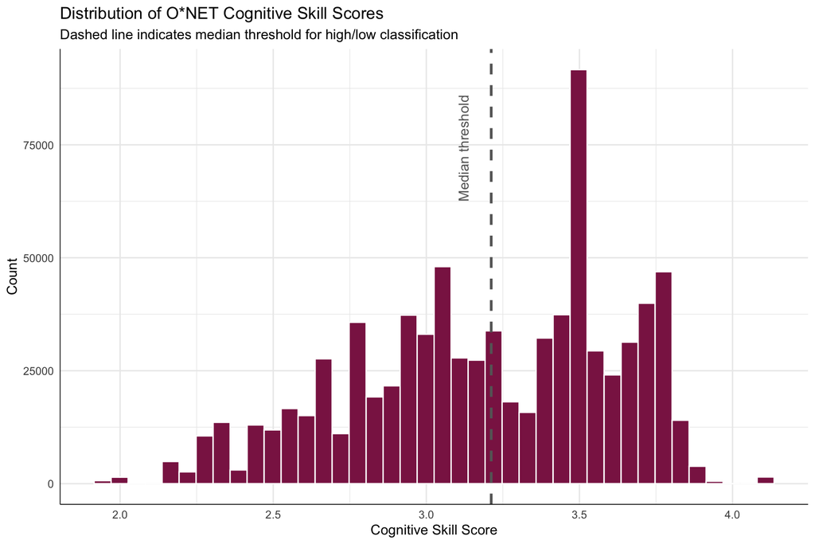

Figure 1

The figures below show the share of workers in high versus low cognitive occupations across four key dimensions: education level, race, industry, and degree field. However, because these figures are purely descriptive, they don’t control for other sources of variation. These patterns reflect the combined influence of all forces involved in the occupation sorting of workers, including differences in education, geography, industry composition, and all other inputs of variation across types.

### 3.1 Education

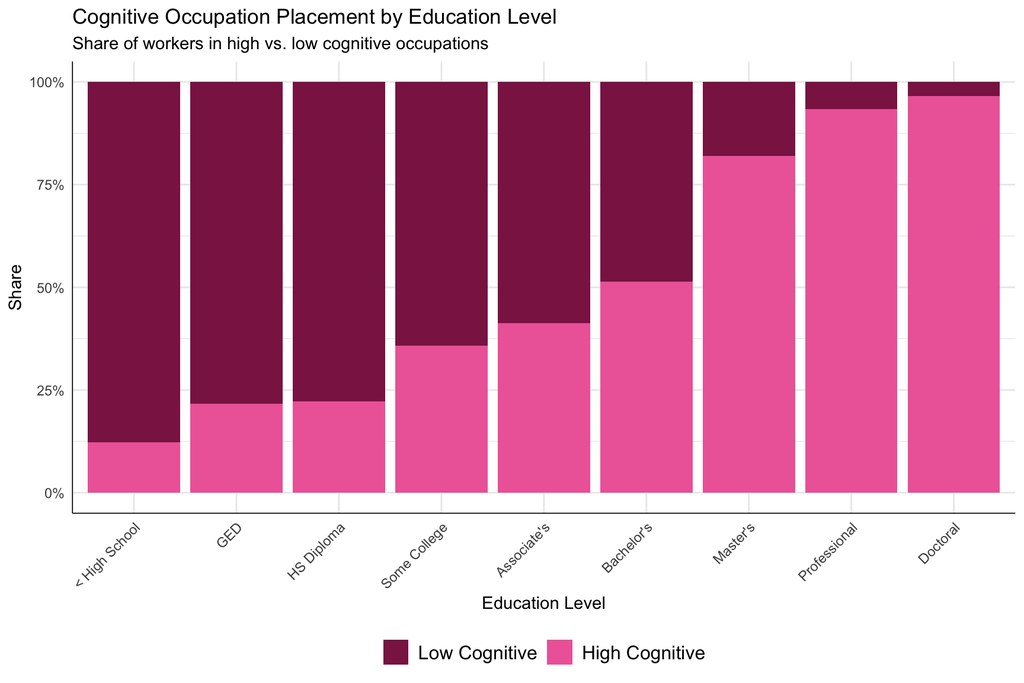

Figure 2

Figure 2 shows a clear monotonic relationship between education attained and cognitive occupation placement, but the pattern isn’t a smooth gradient; it’s a threshold effect centered on the four-year degree. Below the bachelor’s level, most workers end up in low cognitive occupations regardless of whether they have a GED or a high school diploma. At the bachelor’s level the split is roughly even, and above it the balance shifts decisively toward high cognitive work.

### 3.2 Race

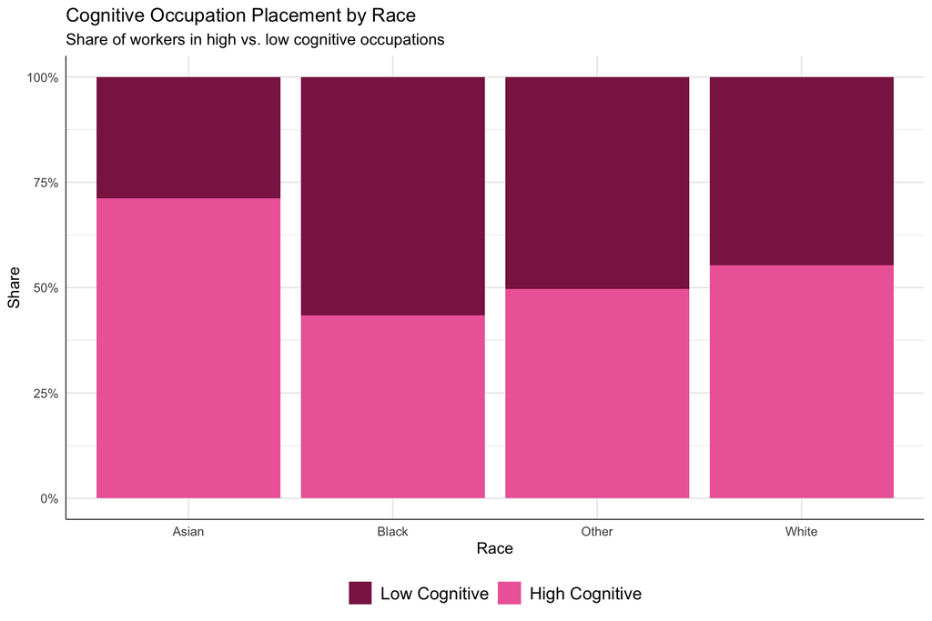

Figure 3

Figure 3 shows substantial variation in cognitive occupation placement across different races. Asian workers have the highest share at roughly 70%, which consistent with the well-documented positive selection of Asian immigrants and their descendants on education and professional credentials. White workers sit just above 50% and Black workers have the lowest share at approximately 44%. However, it’s again, important to note and keep in mind when extracting information from any descriptive visual that these are raw unconditional distributions without present controls.

### 3.3 Industry

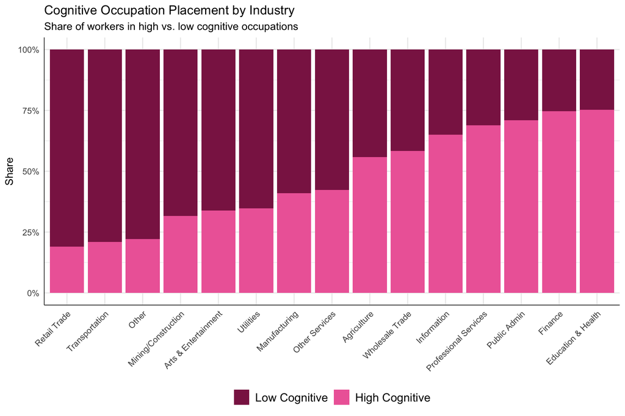

Figure 4

Figure 4 shows a spread nearly as wide as the one spanning across education levels, from roughly 20% high cognitive in Retail Trade and Transportation to 75% in Education and Health and Finance. Industry sorting appears to account for a large share of the observed variation.

### 3.4 Degree Field

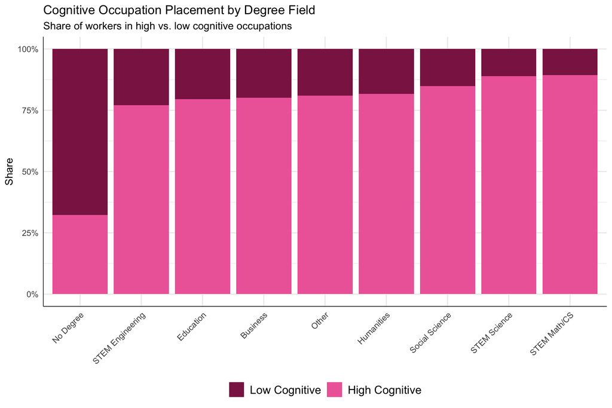

Figure 5

## 4 Methods

### 4.1 Preprocessing

All three prediction models share a common pre-processing pipeline. First, the cognitive score must be removed from the feature set, given that the outcome variable was constructed directly from it. Leaving it in would result in direct data leakage. All categorical predictors are dummy encoded and then numeric predictors are normalized to mean zero and unit variance. Normalizing is not relevant for XGBoost because it’s scale-invariant, but it’s critical for LASSO where coefficient magnitudes need to be comparable across predictors.

### 4.2 Train/Test Split

The sample is split 80/20 into roughly 642,000 training and 160,000 test observations, stratified on the outcome to preserve class balance in both partitions. The test set serves as a strict holdout; every modeling decision is made solely on the training data. Only when all modeling and training decisions are finalized does the test set get evaluated exactly once.

### 4.3 Cross-Validation

All model evaluation and tuning of hyperparameters use a 5-fold stratified cross-validation on the training data. For logistic regression and XGBoost this provides solid and reliable pre-test set performance estimates. In addition those estimates, if used intentionally and preferably a small subset of training data, cross-validating with LASSO can absorb the additional work of selecting the right penalty, which is the value that maximizes the mean area under the curve (AUC), across folds. Determining the best penalty value using tune_grid with LASSO at the cross-validation stage on a comparatively small set of training observations allows you to avoid entirely the computationally intensive use of tune_grid later in the full training-set workflows. The determined best penalty on one-tenth of the data will also be the best penalty on ten-tenths of the data, given the subset is large enough relative to the full data set.

### 4.4 Model Selection

Three prediction models are estimated: logistic regression, LASSO-penalized logistic regression, and XGBoost. For this kind of prediction problem, where the outcome is binary, logistic regression serves as the interpretable baseline rather than linear. Linear regression applied to a binary outcome, as it does in the linear probability model, can predict probabilities beyond the [0,1] interval and by construction, has heteroskedastic errors. Logistic regression maps predictions to the [0-1] interval through the logistic transformation, making it the theoretically appropriate baseline case for binary outcome classification. LASSO takes the base case from logistic regression and augments it with an L1 penalization that forces weak predictors to exactly zero, effectively removing them from the model entirely. Such an attribute makes LASSO well suited for any setting with a high number of dummy categorical predictors, specifically where some variables are potentially redundant or lack any real predictive signal. By effectively removing found-to-be faulty variables from the model, LASSO penalized regression produces a sparse coefficient vector containing only variables that hold predictive value, and net of everything else. XGBoost is a type of ensemble method. It’s specifically a gradient boosted tree that constructs hundreds of shallow, sequential decision trees, where each tree corrects the residual errors of the tree before it. Unlike logistic regression and LASSO, it’s able to detect nonlinear effects, threshold relationships, and high-order interactions between predictors without them being explicitly defined. Which of these three appropriate models most meaningfully outperforms the others is a substantive question about the structure of the data.

### 4.5 Model Specifications

As briefly mentioned earlier, rather than tuning on the full training data, which is, computationally, very costly at 642,000 observations, hyperparameters were selected using a grid search on a stratified 10% training subsample across 27 unique candidate combinations. The best configuration was found to be 200 trees, a learning rate of 0.1, a tree depth of 4 and 6 predictors per split. These hyperparameters were then fixed for the full training run. When the subsample is large enough that hyperparameter estimates are stable, as the consistency of the cross-validation results found them to be, this workflow is a practical and defensible way to avoid the computational and timely costs of tuning parameters with large data sets.

### 4.6 Evaluation Metrics

Five metrics were chosen to be measured and reported: accuracy, AUC, sensitivity, precision, and brier score. Accuracy is the share of correct predictions. It’s intuitive but limited, particularly when classes are imbalanced. Area under the curve (AUC) is the primary evaluating metric, summarizing the model’s ability to distinguish between binary classes across various thresholds. Sensitivity is the rate that true positives are identified among actual high cognitive workers. Precision is the share of predicted high cognitive workers who actually are. Accuracy, AUC, sensitivity and precision all evaluate hard class predictions or rankings. They assess if the model predicted the right class or is able to separate the two classes. Uniquely, the Brier score is the only metric that evaluates the quality of the predicted probabilities themselves. For example, one model predicts a 0.51 probability for someone who ends up in a high cognitive occupation and an alternative model predicts 0.99 for that same person. Under accuracy, sensitivity, and precision, both models get the same credit for a correct prediction. The Brier score penalizes the first model for being uncertain and rewards the second for being confident and right. It’s measuring calibration and sharpness.

## 5 Results

### 5.1 Cross-Validation Performance

| Model | Accuracy | AUC |
| --- | --- | --- |
| Logistic Regression | 0.781 | 0.857 |
| LASSO | 0.781 | 0.857 |
| XGBoost | 0.782 | 0.859 |

All three models land within 0.2 percentage points of each other across the main evaluation metrics. Logistic regression and LASSO are completely indistinguishable from each other. Regularization adds nothing to model performance, indicating that the predictors are carrying real signal rather than noise. XGBoost edges ahead by a slight margin but it’s trivial. Already, the results are suggesting that the relationships present in this prediction problem are largely linear.

### 5.2 Lasso Penalty Tuning

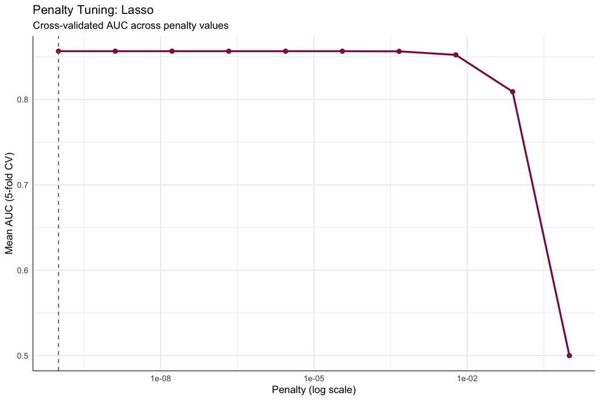

Figure 7

As illustrated in figure 7, the tuning curve is flat across roughly eight orders of magnitude before it steeply drops and collapses to an AUC of 0.5 at the maximum penalty. The optimal penalty, far on the left side of the figure and mostly unregularized, confirms that most predictors carry legitimate signal and as such, aggressive regularization will only hurt.

### 5.3 Test Set Performance

| Model | Accuracy | Sensitivity | Precision | AUC | Brier Score |
| --- | --- | --- | --- | --- | --- |
| Logistic Regression | 0.781 | 0.804 | 0.793 | 0.857 | 0.153 |
| LASSO | 0.781 | 0.803 | 0.793 | 0.857 | 0.153 |
| XGBoost | 0.783 | 0.796 | 0.800 | 0.859 | 0.151 |

The test set results very closely mirror those of cross-validation, confirming that overfitting hasn’t occurred. As was true of the cross-validation of the training data, across all evaluation metrics, the three models perform nearly identically. XGBoost achieves AUC 0.859 whereas both logistic regression and LASSO observe an AUC of 0.857. Again, a marginal difference that’s trivial and negligible in any practical sense. Sensitivity of 0.804 and precision of 0.793 for logistic regression are strong and consistent across all three models as well. Although priors and intuition might begin to suggest to us that the inability of XGBoost to meaningfully improve on logistic regression is a model failure, it’s instead a clear indication of the data taking on a structure that a linear classifier handles essentially as well as a 200-tree ensemble. Adding complexity recovers nothing further.

### 5.4 ROC Curves

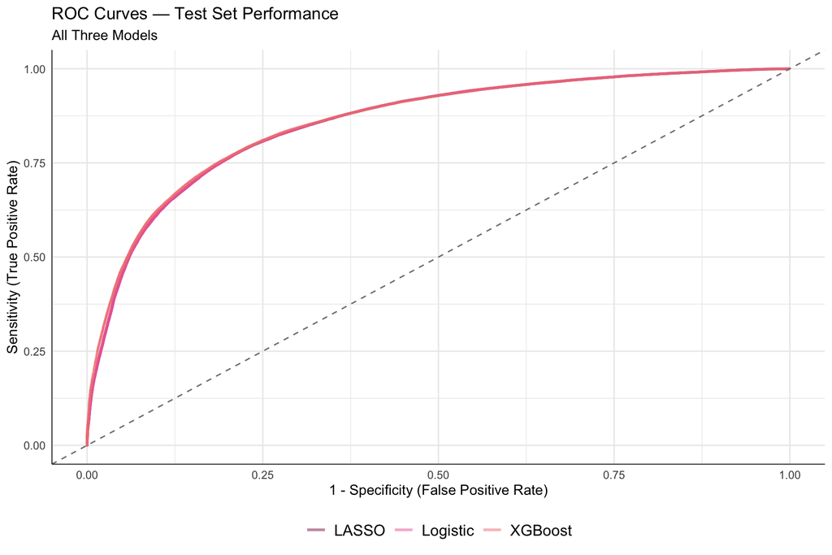

Figure 9

A ROC curve (Receiver Operating Characteristic curve) plots the tradeoff between true positive rate (sensitivity) on the Y-axis and False Positive Rate (1 - specificity) on the X-axis. True positive measuring of all actual positives, how many did you correctly predict as positive? False positive rate measuring of all actual negatives, how many did you incorrectly predict as positive?

Demonstrated in figure 9 by all three curves bowing strongly toward the upper left and being practically indistinguishable from one another across the full threshold range, the models are making essentially identical discriminative judgments no matter where you set the classification cutoff.

### 5.5 Confusion Matrix

A confusion matrix is a table that breaks down a classifier model’s predictions against the actual outcomes that appear in the data. For a binary outcome, it looks as such:

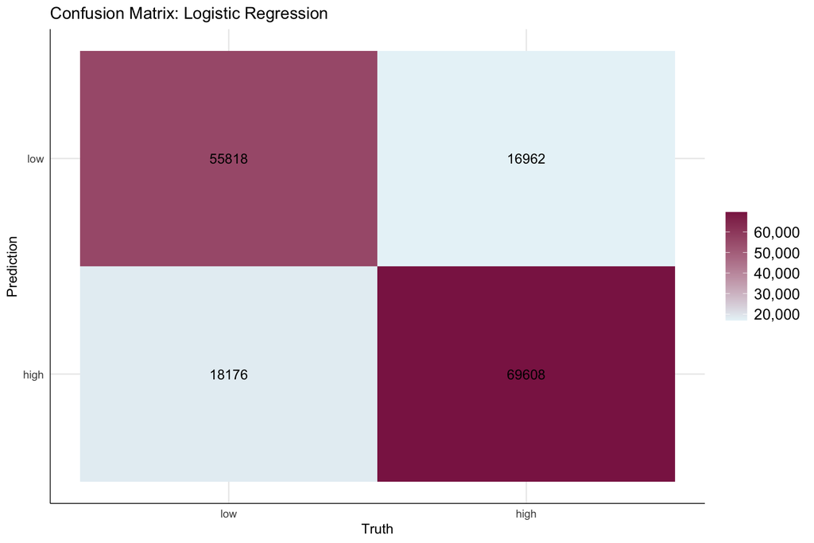

Figure 10

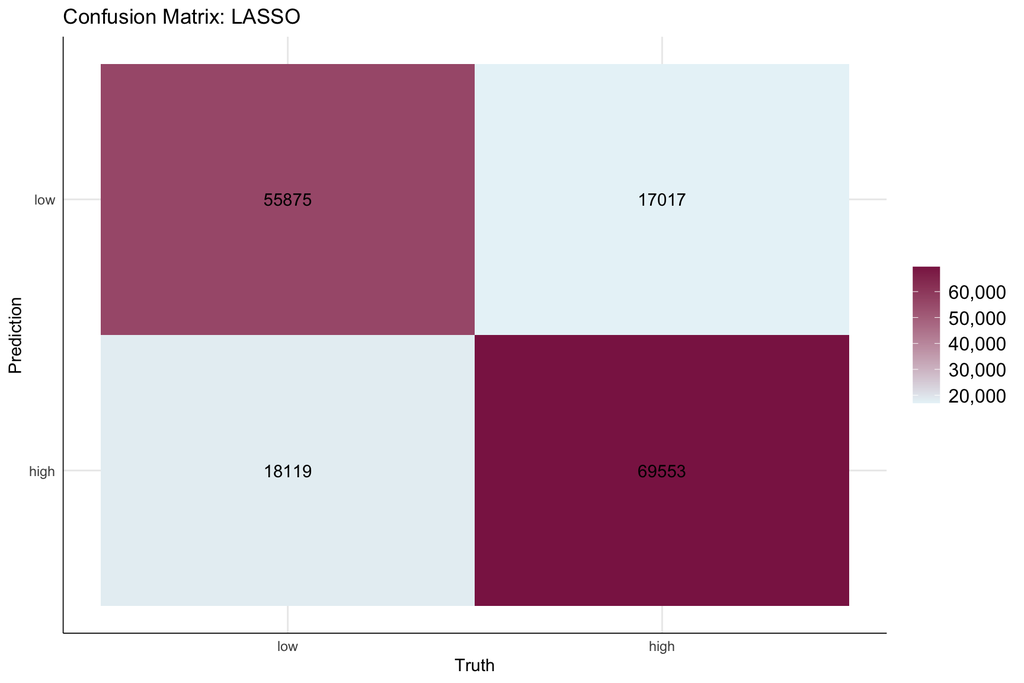

Figure 10

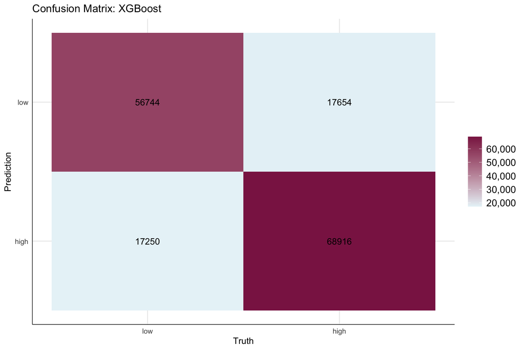

Figure 10

The XGBoost confusion matrix shows 56,744 true negatives and 68,916 true positives, with symmetric errors of roughly 17,000 in each off-diagonal cell. The confusion matrices for Logistic regression and LASSO differ the XGBoost matrix by fewer than 1,000 observations in any cell. The symmetry of the errors confirms no systematic bias toward predictions of either class. The about 11% misclassification rate in each direction illustrates workers whose observable characteristics point in the direction of one class but whose actual occupation points in the other. Many plausible explanations exist for misclassifications such as genuine unpredictability in individual occupational sorting, or the influence of forces we simply don’t observe, like social networks, highly specific skills, idiosyncratic job search outcomes, etc.

## 6 Variable Importance

Variable importance is a measure of how much each predictor contributes to a model’s predictive performance.

### 6.1 Lasso Coefficients and their Importance

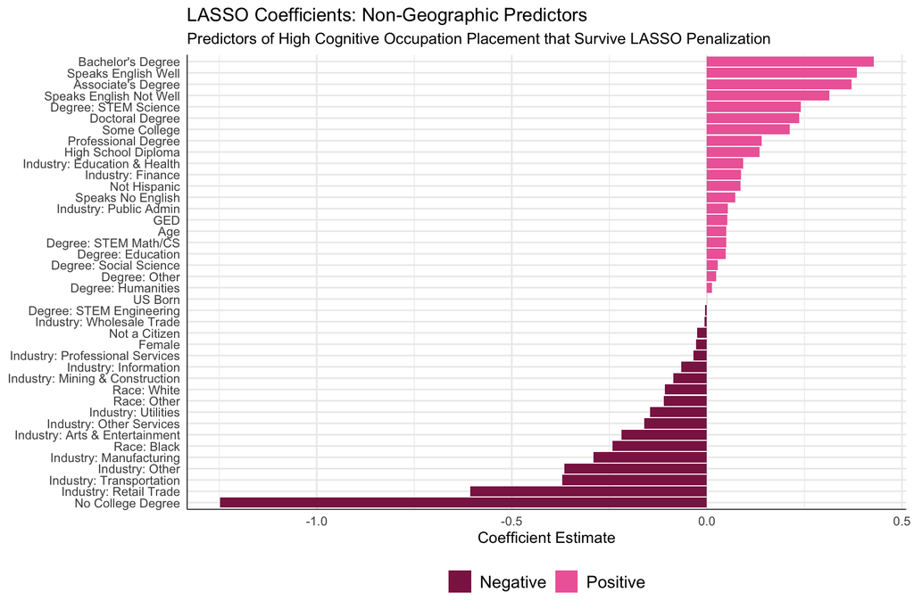

Figure 11

The dominant finding, as it appears, is the absence of a college degree, carrying a coefficient weight of -1.25 which is more than twice the magnitude of any other predictor weight in the model. Industry effects are the next most important group, with retail trade at -0.607 and transportation at -0.371, showing the strongly negative effect, and education and health and finance positive. All of which is consistent with the observed descriptive patterns.

Race carries meaningful conditional coefficients. Black workers sit at -0.242 relative to Asian workers and White workers at -0.108. Gaps that, even after conditioning on education, industry, English proficiency, degree field, and geography, persist. Sex survives at -0.028, and although small, it’s not nothing. Nativity is essentially zero once English proficiency and citizenship are controlled for.

Most surprising to me, however, is English proficiency. Non-English-only speakers, including those who don’t speak English well, are more likely to be in high cognitive occupations than English-only speakers after controlling for everything else. The expected existence of those who don’t speak English well in high cognitive occupations almost certainly reflects positive selection of educated foreign professionals into the US labor market rather than any direct effect of bilingualism on occupational placement.

### 6.2 XGBoost Coefficients and their Importance

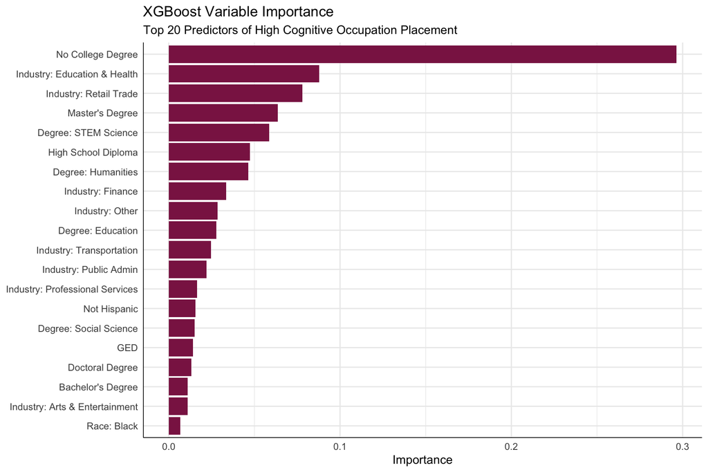

Figure 12

Figure 12 shows the top 20 predictors by XGBoost importance, interpreted as how much each variable contributed to reducing prediction error across all trees. Here, careful interpretation of variable importance is especially important because it’s easier to interpret this incorrectly than correctly. Unlike LASSO coefficients, these carry no directional information. They just measure how much a particular predictor in the model reduces prediction error, regardless of which direction it pushes the prediction. What this visual means to convey is that those are the twenty variables the model most heavily relied on to make its predictions, *not* that these variables are the strongest predictors of being in a high cognitive occupation specifically.

The agreement with LASSO’s variable importance is immediately apparent. No college degree dominates by a wide margin in both models, and retail trade, education and health, STEM science, and race: Black all appear prominently in both rankings. Converging results between a flexible, nonlinear ensemble and a penalized logistic model on the same predictors is strong, sound evidence that those included variables are genuinely driving cognitive occupational sorting. The only difference worth noting is that Master’s degree ranks fourth in XGBoost, but was less prominent and ranked lower in LASSO. Likely, this reflects nonlinear threshold effects in the returns to graduate education that the tree-based model is better positioned to detect.

Understanding variable importance and its implications across different predictive models that are focused on answering the same prediction problem is crucial to correctly and meaningfully make conclusions about your models outcome. High variable importance under XGBoost models indicates that a particular variable was critical for separating the two binary outcome classes. It does not suggest that this variable predicts one class over the other. Paired with the variable importance derived under LASSO coefficients, which *do* provide direction, the two distinct variable importance classifications tell a complete story.